# R Notebook

```r
library(tidyverse)
```

```r
library(ggcorrplot)
library(moments)
```

```r
happy = read.csv('/Users/janvivora/Downloads/2019.csv')
head(happy)
```

|  | Overall.rank | Country.or.region | Score | GDP.per.capita | Social.support | Healthy.life.expectancy | Freedom.to.make.life.choices | Generosity | Perceptions.of.corruption |
| --- | --- | --- | --- | --- | --- | --- | --- | --- | --- |
| 1 | 1 | Finland | 7.769 | 1.340 | 1.587 | 0.986 | 0.596 | 0.153 | 0.393 |
| 2 | 2 | Denmark | 7.600 | 1.383 | 1.573 | 0.996 | 0.592 | 0.252 | 0.410 |
| 3 | 3 | Norway | 7.554 | 1.488 | 1.582 | 1.028 | 0.603 | 0.271 | 0.341 |
| 4 | 4 | Iceland | 7.494 | 1.380 | 1.624 | 1.026 | 0.591 | 0.354 | 0.118 |
| 5 | 5 | Netherlands | 7.488 | 1.396 | 1.522 | 0.999 | 0.557 | 0.322 | 0.298 |
| 6 | 6 | Switzerland | 7.480 | 1.452 | 1.526 | 1.052 | 0.572 | 0.263 | 0.343 |

```r
summary(happy)
```

```
##   Overall.rank    Country.or.region      Score       GDP.per.capita
##  Min.   :  1.00   Length:156         Min.   :2.853   Min.   :0.0000
##  1st Qu.: 39.75   Class :character   1st Qu.:4.545   1st Qu.:0.6028
##  Median : 78.50   Mode  :character   Median :5.380   Median :0.9600
##  Mean   : 78.50                      Mean   :5.407   Mean   :0.9051
##  3rd Qu.:117.25                      3rd Qu.:6.184   3rd Qu.:1.2325
##  Max.   :156.00                      Max.   :7.769   Max.   :1.6840
##  Social.support  Healthy.life.expectancy Freedom.to.make.life.choices
##  Min.   :0.000   Min.   :0.0000          Min.   :0.0000
##  1st Qu.:1.056   1st Qu.:0.5477          1st Qu.:0.3080
##  Median :1.272   Median :0.7890          Median :0.4170
##  Mean   :1.209   Mean   :0.7252          Mean   :0.3926
##  3rd Qu.:1.452   3rd Qu.:0.8818          3rd Qu.:0.5072
##  Max.   :1.624   Max.   :1.1410          Max.   :0.6310
##    Generosity     Perceptions.of.corruption
##  Min.   :0.0000   Min.   :0.0000
##  1st Qu.:0.1087   1st Qu.:0.0470
##  Median :0.1775   Median :0.0855
##  Mean   :0.1848   Mean   :0.1106
##  3rd Qu.:0.2482   3rd Qu.:0.1412
##  Max.   :0.5660   Max.   :0.4530
```

```r
str(happy)
```

```
## 'data.frame':    156 obs. of  9 variables:
##  $ Overall.rank                : int  1 2 3 4 5 6 7 8 9 10 ...
##  $ Country.or.region           : chr  "Finland" "Denmark" "Norway" "Iceland" ...
##  $ Score                       : num  7.77 7.6 7.55 7.49 7.49 ...
##  $ GDP.per.capita              : num  1.34 1.38 1.49 1.38 1.4 ...
##  $ Social.support              : num  1.59 1.57 1.58 1.62 1.52 ...
##  $ Healthy.life.expectancy     : num  0.986 0.996 1.028 1.026 0.999 ...
##  $ Freedom.to.make.life.choices: num  0.596 0.592 0.603 0.591 0.557 0.572 0.574 0.585 0.584 0.532 ...
##  $ Generosity                  : num  0.153 0.252 0.271 0.354 0.322 0.263 0.267 0.33 0.285 0.244 ...
##  $ Perceptions.of.corruption   : num  0.393 0.41 0.341 0.118 0.298 0.343 0.373 0.38 0.308 0.226 ...
```

```r
sum(is.na(happy)) # To check missing values
```

```
## [1] 0
```

Using the viridis package, we can create our own variable with a custom color scheme. This scheme will color countries with higher scores in yellow and lower scores in purple.

```r
v_color <- viridis::viridis(
  n = nrow(happy))

happy$color <- v_color[Matrix::invPerm(
  p = order(
    x = happy$Score))]
```

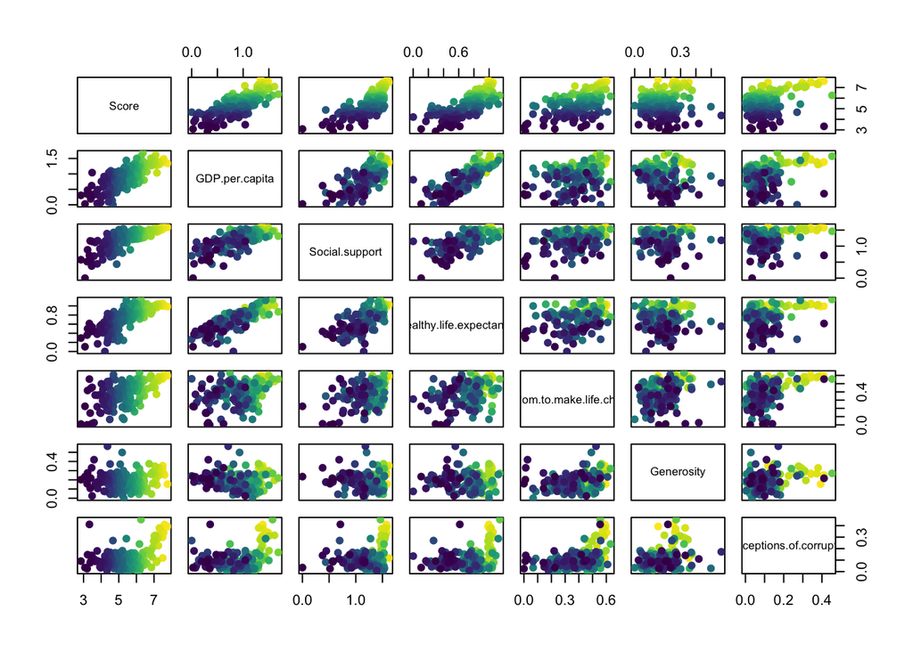

```r
# Correlation Analysis
pairs(
  formula = Score ~ GDP.per.capita + Social.support +
    Healthy.life.expectancy + Freedom.to.make.life.choices +
    Generosity + Perceptions.of.corruption,
  data = happy,
  col = happy$color,
  pch = 19)
```

We can see in the pairs() plots that Score seems to have a strong positive relationship with GDP, social support, and healthy life expectancy. The relationship appears to be slightly weaker between Score and freedom, and much weaker between the generosity and preceptions of corruption variables.

```r
# Multiple linear regression model with all parameters included.

lm_happy <- lm(
  formula = Score ~ GDP.per.capita + Social.support +
    Healthy.life.expectancy + Freedom.to.make.life.choices +
    Generosity + Perceptions.of.corruption,
  data = happy)
summary(lm_happy)
```

```
##
## Call:
## lm(formula = Score ~ GDP.per.capita + Social.support + Healthy.life.expectancy +
##     Freedom.to.make.life.choices + Generosity + Perceptions.of.corruption,
##     data = happy)
##
## Residuals:
##      Min       1Q   Median       3Q      Max
## -1.75304 -0.35306  0.05703  0.36695  1.19059
##
## Coefficients:
##                              Estimate Std. Error t value Pr(>|t|)
## (Intercept)                    1.7952     0.2111   8.505 1.77e-14 ***
## GDP.per.capita                 0.7754     0.2182   3.553 0.000510 ***
## Social.support                 1.1242     0.2369   4.745 4.83e-06 ***
## Healthy.life.expectancy        1.0781     0.3345   3.223 0.001560 **
## Freedom.to.make.life.choices   1.4548     0.3753   3.876 0.000159 ***
## Generosity                     0.4898     0.4977   0.984 0.326709
## Perceptions.of.corruption      0.9723     0.5424   1.793 0.075053 .
## ---
## Signif. codes:  0 '***' 0.001 '**' 0.01 '*' 0.05 '.' 0.1 ' ' 1
##
## Residual standard error: 0.5335 on 149 degrees of freedom
## Multiple R-squared:  0.7792, Adjusted R-squared:  0.7703
## F-statistic: 87.62 on 6 and 149 DF,  p-value: < 2.2e-16
```

The R-squared and adjusted R-squared are close enough to 1 for us to conclude that this model is a good fit.

```r
options(scipen=-100, digits = 3)
anova(lm_happy)
```

|  | Df | Sum Sq | Mean Sq | F value | Pr(>F) |
| --- | --- | --- | --- | --- | --- |
| GDP.per.capita | 1 | 1.21e+02 | 1.21e+02 | 4.25e+02 | 1.69e-45 |
| Social.support | 1 | 1.41e+01 | 1.41e+01 | 4.96e+01 | 6.56e-11 |
| Healthy.life.expectancy | 1 | 4.34e+00 | 4.34e+00 | 1.53e+01 | 1.42e-04 |
| Freedom.to.make.life.choices | 1 | 8.57e+00 | 8.57e+00 | 3.01e+01 | 1.72e-07 |
| Generosity | 1 | 6.66e-01 | 6.66e-01 | 2.34e+00 | 1.28e-01 |
| Perceptions.of.corruption | 1 | 9.15e-01 | 9.15e-01 | 3.21e+00 | 7.51e-02 |
| Residuals | 149 | 4.24e+01 | 2.85e-01 | NA | NA |

The ANOVA shows about the same output, with generosity having a p-value of 0.128 and perceptions of corruption having a p-value of 0.075.

```r
# Testing Multicollinearity for original model
options(scipen=10, digits=3)
vif <- round(car::vif(lm_happy),2)

cat("VIF of Original model\n")
```

```
## VIF of Original model
```